# Plastic Debris

Stuart Watt

# Introduction and Setup

I’m using the following packages:

```r
knitr::opts_chunk$set(fig.align="center")

library(tidyverse)
library(purrr)
library(magrittr)
library(treemap)
# library(data.tree)
# library(igraph)
# library(ggraph)
# library(DiagrammeR)
```

Logged marine debris is available for download [here](http://marinedebris.engr.uga.edu/newmap/). I’m importing data from 2010 till Feb 19th 2020. There doesn’t seem to be data before 2010. The data is reported marine debris.

```r
data <- list.files(path = "data/", full.names = TRUE) %>%
  lapply(FUN = read_csv, col_types = "ififidddddcfcif") %>%
  reduce(rbind)
```

A quick look at the data:

```r
data
```

| ListID | ListName | ItemID | ItemName | LogID | Latitude | Longitude | Altitude | Quantity | Error Radius | Timestamp | Location | Description | Material ID | Material Description |
| --- | --- | --- | --- | --- | --- | --- | --- | --- | --- | --- | --- | --- | --- | --- |
| 22 | Marine Debris Items | 183 | Lumber/Building Materials | 322 | 27.98485 | -82.828376 | -8.800000 | 1 | 2.000000 | 20101230135649 | Clearwater, FL | screw | 8 | PAPER & LUMBER |
| 22 | Marine Debris Items | 183 | Lumber/Building Materials | 323 | 27.98485 | -82.828376 | -8.700000 | 1 | 2.000000 | 20101230135658 | Clearwater, FL | screw | 8 | PAPER & LUMBER |
| 22 | Marine Debris Items | 187 | Cigarettes | 324 | 27.98513 | -82.828306 | 0.200000 | 2 | 2.000000 | 20101230135830 | Clearwater, FL | NA | 4 | PLASTIC |
| 22 | Marine Debris Items | 181 | Bottle or Container Caps | 325 | 27.98548 | -82.828266 | 0.400000 | 1 | 2.000000 | 20101230135932 | Clearwater, FL | NA | 4 | PLASTIC |
| 22 | Marine Debris Items | 181 | Bottle or Container Caps | 326 | 27.98548 | -82.828266 | 0.400000 | 1 | 2.000000 | 20101230135951 | Clearwater, FL | NA | 4 | PLASTIC |
| 22 | Marine Debris Items | 181 | Bottle or Container Caps | 327 | 27.98567 | -82.828340 | 1.400000 | 1 | 2.000000 | 20101230140030 | Clearwater, FL | NA | 4 | PLASTIC |
| 22 | Marine Debris Items | 174 | Aerosol cans | 328 | 27.98575 | -82.828380 | 1.900000 | 1 | 2.000000 | 20101230140105 | Clearwater, FL | NA | 2 | METAL |
| 22 | Marine Debris Items | 207 | Straws | 329 | 27.98551 | -82.828573 | 2.600000 | 1 | 2.000000 | 20101230140205 | Clearwater, FL | NA | 4 | PLASTIC |
| 22 | Marine Debris Items | 185 | Disposable cigarette lighters | 330 | 27.98523 | -82.828593 | 2.000000 | 1 | 2.000000 | 20101230140251 | Clearwater, FL | NA | 4 | PLASTIC |
| 22 | Marine Debris Items | 202 | Plastic or Foam Fragments | 331 | 27.98506 | -82.828383 | 3.000000 | 1 | 2.000000 | 20101230140357 | Clearwater, FL | NA | 4 | PLASTIC |

[output cut: 990 more lines]

# Exploratory Data Analysis

Let’s first check for missing values:

```r
data %>% select_if(function(x) any(is.na(x))) %>% colnames()
```

```
[1] "Location"    "Description"
```

So only these columns contain missing values. Lets see the amount of unique values for each column:

```r
data %>% apply(2, function(x) length(unique(x)))
```

```
              ListID             ListName               ItemID
                   1                    1                   55
            ItemName                LogID             Latitude
                  55               363368               142707
           Longitude             Altitude             Quantity
              136490               135214                  496
        Error Radius            Timestamp             Location
               18374               248436                 1458
         Description          Material ID Material Description
                8494                    8                    8
```

Both “ListID” and “ListName” don’t give us any information, so we will remove them both.

```r
data <- data %>% select(-ListID,-ListName)
```

Lets see if there are any “ItemNames” associated with more than one “Material Descriptions”.

```r
# data %>% select(`Material Description`, ItemName) %>%
#   group_by(`Material Description`) %>%
#   mutate(numberOf)
#   summarise(distinct)
data %>% select(`Material Description`, ItemName) %>%
  distinct() %$%
  table(ItemName) %>%
  as_tibble() %>%
  filter(n > 1)
```

| ItemName | n |
| --- | --- |
| Rubber Gloves | 2 |

So rubber gloves are associated with two material descriptions, but otherwise a one to many relationship exists between “Material Description” and “ItemName”.

```r
data %>% select(`Material Description`, ItemName, Quantity) %>%
  filter(ItemName == "Rubber Gloves") %>%
  group_by(`Material Description`) %>%
  summarise(Quantity = sum(Quantity))
```

| Material Description | Quantity |
| --- | --- |
| PLASTIC | 2114 |
| RUBBER | 155 |

It seems that most rubber gloves are classified as plastic rather than rubber.

```r
data %>% select(`Material Description`, ItemName, Description) %>%
  filter(ItemName == "Rubber Gloves", !is.na(Description)) %>%
  distinct()
```

| Material Description | ItemName | Description |
| --- | --- | --- |
| PLASTIC | Rubber Gloves | Found on wassaw island Oct. 21 with beach walk |
| PLASTIC | Rubber Gloves | undefined |
| PLASTIC | Rubber Gloves | thermal |
| PLASTIC | Rubber Gloves | Near water |
| PLASTIC | Rubber Gloves | Taste of Omaha Cleanup |
| PLASTIC | Rubber Gloves | 2 diff kinds |
| PLASTIC | Rubber Gloves | Latex |
| PLASTIC | Rubber Gloves | Hose |
| PLASTIC | Rubber Gloves | Cap |
| PLASTIC | Rubber Gloves | Vial |

[output cut: 8 more lines]

All non-missing descriptions of rubber gloves are in the described as plastic.

Distribution of observed debris:

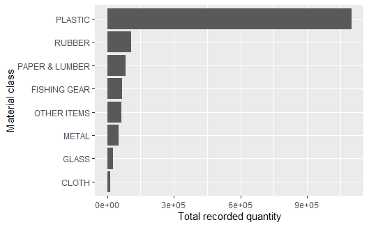

```r
data %>% select(Quantity,Description,`Material Description`) %>%
  group_by(`Material Description`) %>%
  summarise(Quantity = sum(Quantity)) %>%
  ggplot(aes(x = reorder(`Material Description`, Quantity), y = Quantity)) +
    geom_col() +
    ylab("Total recorded quantity") +
    xlab("Material class") +
    coord_flip()
```

A tree map of material quantities:

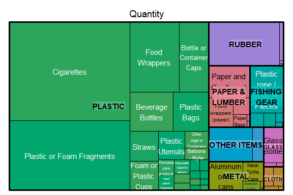

```r
# data.Hierarchy <- data %>%
#   select(`Material Description`, ItemName) %>%
#   filter(ItemName != "Rubber Gloves") %>%
#   distinct() %<>%
#   mutate_if(is.factor, as.character)
data %>%
  select(`Material Description`, ItemName, Quantity) %>%
  group_by(`Material Description`, ItemName) %>%
  summarise(Quantity = sum(Quantity)) %>%
  treemap(index = c("Material Description", "ItemName"),
          vSize = "Quantity", draw = TRUE)
```

```r
# data.Hierarchy$pathString <- paste("Debris",
#                                    data.Hierarchy$`Material Description`,
#                                    data.Hierarchy$ItemName,
#                                    sep = '/')
#
# data.Hierarchy %>%
#   as.Node() %>%
#   as.igraph(directed = TRUE) %>%
#   ggraph(layout = "circlepack") +
#   geom_node_circle() +
#   geom_node_text(aes(label= name, filter=leaf, size = 0.1)) +
#   theme_void() +
#   theme(legend.position="FALSE") +
#   coord_equal()
#
# data.Hierarchy %>%
#   as.Node() %>%
#   as.igraph(directed = TRUE) %>%
#   ggraph(layout = "circlepack", circular = FALSE) +
#   geom_edge_diagonal() +
#   geom_node_text(aes(label = name), repel = FALSE, angle = 90, hjust = 1,
#                  nudge_y = -0.1) +
#   ylim(-6, NA) +
#   theme(legend.position="none")
```

Perhaps some of the debris is not actually from the sea, but rather from people littering by the coastline?

```r
data %>% filter(`Material Description` == "PLASTIC") %>%
  select(ItemName) %>%
  group_by(ItemName) %>%
  count(sort = TRUE)
```